# CASE STUDY

This case study looks at three models. They are all discrete-time state-space models of the kind $$ \left\lbrace \begin{aligned} \boldsymbol x_{t+1} &= f_i(\boldsymbol x_t, \boldsymbol u_t, \boldsymbol \theta_i) + \boldsymbol w_t \,,\\ \boldsymbol z_t &= \textbf{H} \boldsymbol x_t\,,\\ \boldsymbol y_t &= \boldsymbol z_t + \boldsymbol v_t \,, \end{aligned} \right.$$ where $\boldsymbol x_t \sim \mathcal{N}(\boldsymbol \mu_t, \boldsymbol \Sigma_t)$ are the latent states at time $t$, $\boldsymbol u_t \sim \mathcal{N}(\boldsymbol u_t, \boldsymbol \Sigma_u)$ are the control inputs, $\boldsymbol \theta_i \sim \mathcal{N}(\hat{\boldsymbol \theta}_i, \boldsymbol \Sigma_{\theta,i})$ are the model parameters for model $i$, $\boldsymbol w_t \sim \mathcal{N}(\boldsymbol 0, \textbf{Q})$ is i.i.d. process noise, $\boldsymbol z_t$ are the measured states and $\boldsymbol v_t \sim \mathcal{N}(\boldsymbol 0, \textbf{R})$ is i.i.d. measurement noise.

### Set-up

We begin by importing some standard packages

```python
# Standard math package
import numpy as np
np.set_printoptions(4)

# Package for plotting results
import matplotlib.pyplot as plt
```

Next we have some flags that we can set as we wish

```python
# Number of time steps each experiment should last
num_time_steps = 50

# Number of initial experiments (before we begin optimal design of experiments)
num_init_exp = 3
```

### Experimental data

Next we want to import and the case study $\texttt{nonlinear2}$ from the DoEpy package.

The variables are

- DM - the data-generating model, that we use to run "experiments".
- Ms - the candidate models, one of which has the same structure as the data-generating model.

```python
from doepy.case_studies.discrete_time import nonlinear2

DM, Ms = nonlinear2.get()
```

In order to work with the data-generating model, we want to wrap some extra functionality around the bare transition function that we're given in the case study code. We do this by hooking the data-generating model to a DoEpy discrete-time state space model.

(Obviously, this is just for the computer simulations, in a real setting we cannot wrap a DoEpy function around our experimental data generator, e.g. a chemical plant.)

```python
from doepy.models import CandidateWrapper
from doepy.models.discrete_time import dtModel

datagen = dtModel(CandidateWrapper(**DM.get_candidate_dict()))
```

Now we create some initial experimental data

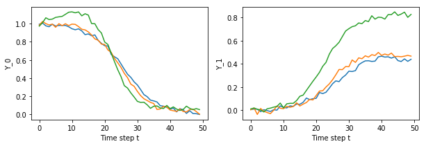

```python
# Generate experiment input sequences
U_data = DM.get_initial_experiments(num_init_exp, num_time_steps)
# Run experiments and collect measurements
Y_data = [ datagen.sample(None, U)[1] for U in U_data ]

# Time step sequence
T = np.arange(num_time_steps)

# Plot experimental observations
fig, axs = plt.subplots(1,2,figsize=(10,3))
for Y in Y_data:
    axs[0].plot(T, Y[:,0])
    axs[1].plot(T, Y[:,1])

axs[0].set_xlabel('Time step t')
axs[0].set_ylabel('Y_0')
axs[1].set_xlabel('Time step t')
axs[1].set_ylabel('Y_1')
plt.show()
```

### Initialise surrogate models

The goal is to find which one of the models in Ms that is the "true" model, i.e. has the same model structure as the data-generating model. To do this, we need to design additional experiments.

To find the optimal next experiment, we want to find the input sequence that maximises the divergence between the rival models' predictive distributions. In order to find the predictive distributions, we replace the original models with surrogate models. Our choice of surrogates use Gaussian process (GP) regression.

In DoEpy, we begin by wrapping a surrogate model class around the original models. Since our original models are discrete-time state space models, we wrap the discrete-time GP state space class around them.

```python
from doepy.models.discrete_time import dtGPModel

dicts  = [ M.get_candidate_dict() for M in Ms ]
models = [ dtGPModel(CandidateWrapper(**d)) for d in dicts ]
```

### Parameter estimation

Our models come with model parameters that we need to estimate to fit the model predictions to the experimental data. We define a function for fitting parameters of a DoEpy model object.

```python
from doepy.param_estim.state_space import least_squares

def fit_parameters (model, p_inital_guess, p_bounds):
    # Initial states
    X0 = [ model.x0 ] * len( U_data )
    # Parameter estimation
    p  = least_squares(model, p_inital_guess, p_bounds, X0, U_data, Y_data)['x']
    return p
```

Then we call the parameter fitting function for each model. Because we will assume the model parameters are Gaussian distributed according to $\boldsymbol \theta_i \sim \mathcal{N}(\hat{\boldsymbol \theta}_i, \boldsymbol \Sigma_{\theta,i})$, what we are estimating is the mean parameter value $\hat{\boldsymbol \theta}_i$.

```python
for i,model in enumerate( models ):
    # Initial guess for model parameter values
    p_init   = Ms[i].p0
    # Bounds on model parameter values
    p_bounds = Ms[i].p_bounds

    # Set parameter estimate as model parameter mean
    model.p_mean = fit_parameters(model, p_init, p_bounds)
```

Plot the predictions of the models (M1, M2 and M3) with fitted parameters

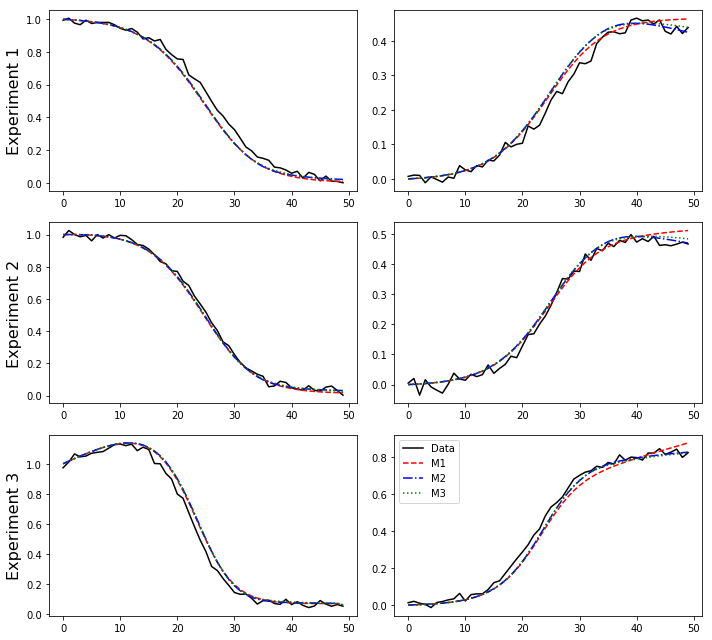

```python
fig, axs = plt.subplots(num_init_exp, 2, figsize=(10, num_init_exp*3))
cols, ls = ['r', 'b', 'g'], ['--', '-.', ':']

for j in range(num_init_exp):
    axs[j][0].set_ylabel('Experiment %d'%(j+1), rotation=90, fontsize=16)
    axs[j][0].plot(T, Y_data[j][:,0], 'k')
    axs[j][1].plot(T, Y_data[j][:,1], 'k', label='Data')

    for i,model in enumerate(models):
        X, Y = model.predict(None, U_data[j])
        axs[j][0].plot(T, Y[:,0], ls[i]+cols[i])
        axs[j][1].plot(T, Y[:,1], ls[i]+cols[i], label=model.name)

plt.legend()
plt.show()
```

### Train surrogate models

The GP surrogate models essentially work by interpolating between training data. For our surrogates to accurately replicate predictions of the original models, we have to choose training data in a clever way. The DoEpy package helps with this.

The user needs to define bounds on $\boldsymbol x$, $\boldsymbol u$ and $\boldsymbol \theta$ samples. The bounds on $\boldsymbol x$ and $\boldsymbol u$ will restrict the allowed design space for design of experiments later. The bounds on $\boldsymbol \theta$ samples should be some small area around the best-fit model parameters $\hat{\boldsymbol \theta}$ to help us approximate the model prediction gradient with respect to $\boldsymbol \theta$ at $\boldsymbol \theta = \hat{\boldsymbol \theta}$.

In our case, the bounds on $\boldsymbol x$ and $\boldsymbol u$ are already specified in the case study code, and requested using model.x_bounds and model.u_bounds. We choose the model parameter bounds as $\hat{\boldsymbol \theta} \pm 5\%$.

```python
def p_sample_bounds (model):
    return model.p_mean[:,None] * np.array([0.95, 1.05])
```

Now we can train the surrogate models

```python
for i,model in enumerate(models):
    model.train(p_bounds=p_sample_bounds(model))
```

Now we have GP surrogate models that we can use to make predictions for any latent state $\boldsymbol x$ and control input $\boldsymbol u$. For inputs far away from our training data (e.g. outside the bounds we put on $\boldsymbol x$ and $\boldsymbol u$) the surrogate model predictions will most likely differ significantly from the predictions of the original models. However, within the bounds, we hope that the surrogate model predictions are accurate. Because we're using probabilistic GP surrogate models, we can compute the variance of our predictions.

### Model parameter covariance

Now we wish to approximate the model parameter covariance. The DoEpy package implements a (first-order) Laplace approximation for this purpose.

```python
from doepy.param_covar import state_space_laplace

for model in models:
    model.p_covar = state_space_laplace(model, U_data)
```

### Approximate marginal predictive distributions

We now wish to marginalise out the model parameters, i.e. compute the models' predictive distributions taking the parametric uncertainty into account: $$p( \boldsymbol z_t \,|\, \boldsymbol x_0, \boldsymbol u_1, \dots, \boldsymbol u_{t-1}, \mathrm{Data} ) =\int p( \boldsymbol z_t \,|\, \boldsymbol x_0, \boldsymbol u_1, \dots, \boldsymbol u_{t-1}, \boldsymbol \theta ) p( \boldsymbol \theta \,|\, \mathrm{Data} ) \mathrm{d} \boldsymbol \theta \,.$$ We use the Gaussian approximation of the parametric uncertainty, and first-order Taylor expansion of the GP surrogate predictions to approximately marginalise out the model parameters.

Below we plot the marginal predictive mean, with two standard deviations.

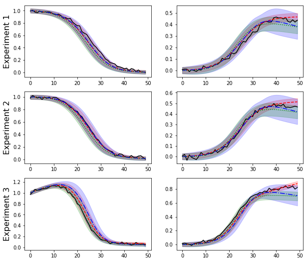

```python
fig, axs = plt.subplots(num_init_exp, 2, figsize=(10, num_init_exp*3))
cols, ls = ['r', 'b', 'g'], ['--', '-.', ':']

num_models = 3   # Number of rival models
num_meas   = 2   # Number of measured states

# For saving predictions
Y_pred   = [ ]
S_Y_pred = [ ]

for j in range(num_init_exp):
    axs[j][0].set_ylabel('Experiment %d'%(j+1), rotation=90, fontsize=16)
    axs[j][0].plot(T, Y_data[j][:,0], 'k')
    axs[j][1].plot(T, Y_data[j][:,1], 'k', label='Data')

    # For saving predictions
    Y   = np.zeros(( num_models, num_time_steps, num_meas ))
    S_Y = np.zeros(( num_models, num_time_steps, num_meas, num_meas ))

    for i,model in enumerate(models):
        # Initial latent state mean and covariance
        x0   = model.x0
        S_x0 = model.x0_covar

        # Compute latent state predictions
        X, S_X = model.predict_x_dist(x0, S_x0, U_data[j])

        # Translate latent state predictions to observed state predictions
        Y[i], S_Y[i] = model.predict_y_dist(X[:-1], S_X[:-1])

        for d in range(2):
            # Mean and two standard deviations
            y, s  = Y[i,:,d], 2*np.sqrt( S_Y[i,:,d,d] )
            axs[j][d].plot(T, y, ls[i]+cols[i], label='%s'%model.name)
            axs[j][d].fill_between(T, y+s, y-s, color=cols[i], alpha=0.2)

    # Save predictions
    Y_pred.append( Y )
    S_Y_pred.append( S_Y )

plt.show()
```

### Model discrimination

We can assess which model performs best by computing how well the model predictions fit the data. We start by stacking all the experimental observations and the predictive distributions into single matrices.

```python
Y_all = np.vstack( Y_data )
Z_all = np.concatenate( Y_pred, axis=1 )
S_all = np.concatenate( S_Y_pred, axis=1 )
```

First, we compute the relative marginal likelihoods $$ \mathrm{RML}_i = \frac{\mathcal{N}(\textbf{Y}\,|\,\textbf{Z}_i,\textbf{S}_i)}{\sum_j \mathcal{N}(\textbf{Y}\,|\,\textbf{Z}_j,\textbf{S}_j)} $$ A score close to 1 means that a model is more likely to be the "true" model.

```python
from doepy.model_discrimination import relative_likelihood

rel_lik = relative_likelihood(Y_all, Z_all, S_all)

# Print result
for rl, model in zip(rel_lik, models):
    print('%s: %f  (log10: %f)'%(model.name, rl, np.log10(rl)))
```

```
M1: 1.000000  (log10: -0.000000)
M2: 0.000000  (log10: -12.906560)
M3: 0.000000  (log10: -43.730478)
```

Second, we compute the symmetric KL divergence between the distributions $\mathcal{N}(\textbf{L}_t^{-1}(\boldsymbol y_t-\boldsymbol z_t), \textbf{I})$ and $\mathcal{N}(\boldsymbol 0, \textbf{I})$ for each time step $t$, where $\textbf{S} = \textbf{L} \textbf{L}^\top$ is the Cholesky decomposition of the predictive variance.

A divergence close to 0 means that a model is more likely to be the "true" model.

```python
from doepy.model_discrimination import symmetric_KL

kl_symmetric = symmetric_KL( Y_all, Z_all, S_all )

# Print result
for kl, model in zip(kl_symmetric, models):
    print('%s: %f'%(model.name, kl ))
```

```
M1: 0.113602
M2: 0.191289
M3: 0.876985
```

We see that, looking at both the marginal likelihood and the KL divergence, model M1 scores best. We could choose M1 as the most likely "true" model. There are two reasons to be cautious here.

- It is well known that the marginal likelihood tends to be over-confident. Small fluctuations can have a massive impact on the relative marginal likelihoods.
- The KL divergence scores for both M1 and M2 are much lower than for M3. We also do not know what these numbers mean. Is 0.114 good? Is 0.877 bad?

Thirdly, we perform a $\chi^2$ adequacy test.

A score of 1 means a perfect fit. A score close to 0 means a model is likely to be inadequate.

```python
from doepy.model_discrimination import chi2_adequacy_test

num_param = [ model.num_param for model in models ]
chi2_test = chi2_adequacy_test(Y_all, Z_all, S_all, num_param)

# Print result
for chi2, model in zip(chi2_test, models):
    print('%s: %f'%(model.name, chi2 ))
```

```
M1: 0.000000
M2: 0.395605
M3: 0.000000
```

We see that for the $\chi^2$ test, model M2 scores the best. So the different tests give different results.

Therefore we wish to design additional experiments and collect more measurements before making any decisions. How DoEpy helps with the design of experiments is shown in a different tutorial.